# Bayesian optimization

Computer-Aided Medical Diagnostics, MPA-PRM (from 2027/28 Applied AI in Life Sciences, MPA-AUI)

Tomáš Vičar

Department of Biomedical Engineering · FEEC, Brno University of Technology

2026-09-14

## What you should be able to do after today

Frame the problem

What are the variables, the objective and the bounds?

Read the landscape

The nearest valley versus the deepest one.

Model what you do not know

Why must a model also say **where it is unsure**?

Choose where to ask next

Which point deserves one of your twenty expensive experiments?

## 1 · What is an optimization problem

> When there are many possible settings, how do we systematically pick the best one?

## How do you set the shower tap?

[figure not shown]

Two handles change:

- the flow of hot water $q_\mathrm{h}$;
- the flow of cold water $q_\mathrm{c}$.

Goal: a pleasant **temperature** and enough **total flow**.

Which way do you turn — and by how much?

## Anatomy of the problem

[figure not shown]

$$\begin{aligned}
\text{minimize}\quad &\bigl(T(\mathbf x)-38.5\bigr)^2+\lambda\bigl(Q(\mathbf x)-12\bigr)^2\\
\text{subject to}\quad &0\leq q_\mathrm{h}\leq12,\quad 0\leq q_\mathrm{c}\leq12
\end{aligned}$$

- **decision variables** $\mathbf x=(q_\mathrm{h},q_\mathrm{c})$;
- **objective** — both misses merged into **one number**;
- **weight** $\lambda$ — flow error versus temperature error;
- **bounds** — the range of the handles.

## General formulation

### The problem

$$\mathbf x^\star \in \mathop{\arg\min}_{\mathbf x\in X} f(\mathbf x)$$

- $\mathbf x$ — **decision variables**;
- $f$ — **objective** (cost, loss, error);
- $X$ — **feasible set** — today a **box** $\mathbf l\leq\mathbf x\leq\mathbf u$;
- $\mathbf x^\star$ — **minimizer**.

### Two conventions

**A value is not a point.** $p^\star=\min f(\mathbf x)$ is a **number**, $\mathbf x^\star$ is **where** it is attained — we prescribe a regimen, not a score.

**We always minimize.** Maximizing $u$ is minimizing $-u$:

$$\max_{\mathbf x\in X} u(\mathbf x)\quad\Longleftrightarrow\quad\min_{\mathbf x\in X}\,-u(\mathbf x)$$

Same minimizer, the value flips sign.

## When there is a formula: differentiate

Fuel consumption per 100 km as a function of speed — two opposing effects:

- losses that depend on **time** → $A/v$;
- **aerodynamic drag** → $Bv$.

$$\begin{aligned}
\text{minimize}\quad & f(v)=\frac{A}{v}+Bv+C\\
\text{subject to}\quad & 50\leq v\leq130
\end{aligned}$$

$$f'(v^\star)=0\;\Longrightarrow\;v^\star=\sqrt{A/B}\approx 89\ \text{km/h}$$

Inside the bounds — otherwise the optimum sits **on the bound**.

[figure not shown]

→ speed $v$

## Closed form or iteration?

### Closed form

Differentiate, set to zero, solve.

- needs a **formula** for $f$;
- exact, in one step;
- the fuel curve, least squares.

### Iteration

Start somewhere, improve, repeat — e.g. **gradient descent**:

$$\mathbf x_{k+1}=\mathbf x_k-\eta\,\nabla f(\mathbf x_k)$$

- $\nabla f$ — the slope in every direction, points **uphill**; $\eta$ — step size;
- needs only to **evaluate** $f$ and its slope;
- neural networks — and almost everything else.

Third case, today’s: no formula, no derivative — and every evaluation is expensive.

## Local versus global minimum

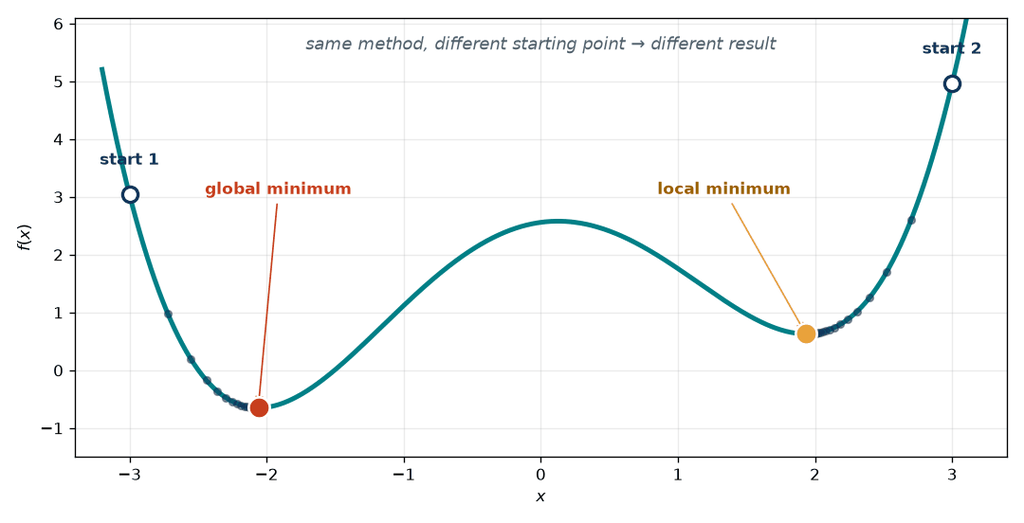

- **Local minimum:** the best within a neighbourhood.
- **Global minimum:** the best in the whole feasible set.
- A local method ends in the valley its start $\mathbf x_0$ leads to.

## A Gin and Tonic: what if there is no formula?

$$\mathbf x=(x_\text{gin},x_\text{tonic},x_\text{lemon})^\mathsf T$$

$$\begin{aligned}
\text{minimize}\quad &-T(\mathbf x)\\
\text{subject to}\quad &\mathbf 0\leq\mathbf x\leq\mathbf u
\end{aligned}$$

Taste $T(\mathbf x)$ as high as possible; the bounds are the glass.

[figure not shown]

$T(\mathbf x)$ has **no formula and no derivative** — one evaluation is one sip, and there are only a few. A **black-box** problem: the rest of the lecture.

## 2 · The expensive black box

> When one evaluation costs hours of computing, thousands of euros or one patient, the question stops being *how to search* and becomes **where to ask next**.

## Where to drill

[figure not shown]

- An **oil prospector**, an unexplored area: no formula, no derivative.
- The only way to learn one value: **drill a hole** — tens of millions, months.
- Not “how do I find the maximum”, but **“where do I drill right now”**.

## The same problem in biomedicine

Running example: a **chemotherapy dosing schedule**.

| what we look for | symbol | range |
| --- | --- | --- |
| dose per cycle | $d$ | 20 to 100 mg/m² |
| interval between cycles | $T$ | 10 to 35 days |

Score = **tumour shrinkage − toxicity − burden**.

One evaluation = the **patient response to a whole schedule**: twenty minutes of simulation, in reality weeks of a trial.

[figure not shown]

## Problem statement

$$\max_{\mathbf x\in X} f(\mathbf x),\qquad
X=[20,100]\times[10,35],\qquad
\mathbf x=(d,T)$$

Noisy measurement:

$$y_i=f(\mathbf x_i)+\varepsilon_i,\qquad
\varepsilon_i\sim\mathcal N(0,\sigma_\varepsilon^2),\quad \sigma_\varepsilon=2.0$$

- about $f$ we know **nothing**: no formula, no derivative, no promise of a single peak;
- we can only **evaluate it, expensively, at a point**;
- $N$ — the budget, $n$ — points measured so far.

The formulation is the one from the opening block — what changed is the **budget**.

### Who is out of the game

| approach | typically needs |
| --- | --- |
| sampling-based global search | $10^4$ to $10^6$ evaluations |
| **today** | $N=20$ to $100$ |

$10^4$ simulator runs at twenty minutes each: **almost five months of computing**.

## Grid and random are not enough

[figure not shown]

- Only one parameter matters: a $5\times5$ grid tries **five** values of it, random search **twenty-five**.
- Ten values per variable is $10^n$ evaluations; even five values on four parameters is $5^4=625$ runs.
- Both are **blind**: the twenty-fifth point knows nothing about the first twenty-four.

## 3 · A cheap model of an expensive function

> When every evaluation is expensive, it pays to think for a while before you spend one — and thinking can only be done over a model.

## The idea behind the whole method

[figure not shown]

- The expensive function is replaced by a cheap **surrogate model** built from the measured points.
- The next point is **computed**, not drawn — from the estimate **and the band**.
- Where the model is guessing, it **says so about itself**.

## Fitting a curve is not enough

[figure not shown]

A **single curve** gives no reason to go anywhere but its maximum.

**Infinitely many curves** fit the same points — **their spread is the missing information**.

The most valuable thing about the model is not its estimate but its **uncertainty**.

## The Gaussian process

[figure not shown]

- A **GP** is a **distribution over functions** — whole curves are drawn from it, ten of them here.
- No data: every smooth curve is plausible; six measurements: only curves **through the points** survive.
- The **band** is their spread: $\mu$ the average of the surviving curves, $\sigma$ their scatter.

## Every measurement crosses out curves

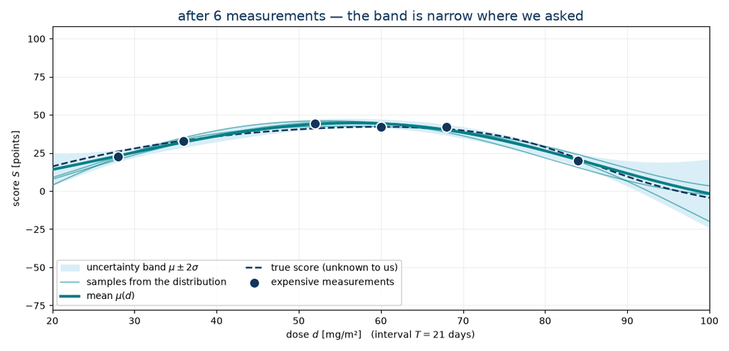

One measurement at a time:

- the band **narrows** at data, reopens far away;
- noise keeps it above zero;
- the sixth question is smarter than the first.

**Why normal?** Prior + data stays normal, so $\mu$ and $\sigma$ come from **a single formula**.

## The kernel: how far can I see?

My only input: the **kernel** — an assumption about smoothness

$$k(\mathbf x, \mathbf x') = A^2\exp\!\left(
-\frac{\lVert\mathbf x-\mathbf x'\rVert^2}{2\ell^2}\right)$$

- $\ell$ — “**how far I can see**”: how far from a measurement the model still trusts it;
- $A$ — the size of the swings it expects.

Two knobs, and they are **fitted to the data** like any other model (here $\ell=0.38$ on the unit box, $A=43$).

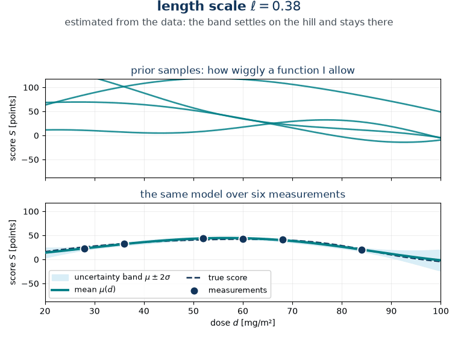

## What comes out of the model

$K$ — similarity between measured points, $\mathbf k_*$ — the new point versus them:

$$\begin{aligned}
\mu(\mathbf x)&=\mathbf k_*^\mathsf T\,(K+\sigma_\varepsilon^2 I)^{-1}\,\mathbf y\\[2pt]
\sigma^2(\mathbf x)&=k(\mathbf x,\mathbf x)-\mathbf k_*^\mathsf T\,
(K+\sigma_\varepsilon^2 I)^{-1}\,\mathbf k_*
\end{aligned}$$

One solve of a linear system — **microseconds**.

$\mathbf y$ appears **only in $\mu$**: $\sigma$ depends on **where** I measured, not on what came out.

[figure not shown]

[A Gaussian process in fifteen lines, no library](https://github.com/tomasvicar/AUI-public/blob/master/lectures/bayesian-optimization/code/common.py)

## Limits of the Gaussian process

### Where it runs out of breath

- an $n\times n$ matrix inverse, cost $\sim n^3$ — thousands of measurements are too many;
- **high dimension**: the band never narrows — ceiling about **twenty parameters**;
- a bad kernel quietly passes its assumption on to the result.

### What is used instead

- **tree-structured Parzen estimator** (TPE) — models good versus bad settings, not the function, and needs **no distance**: categories and branching spaces are fine — **block 6**.

“Bayesian optimization” is a **frame, not one algorithm**: any model that delivers an **uncertainty** with every estimate will do.

## 4 · Where to ask next

> The model returns two numbers — what it expects and what it does not know — and out of them one single decision has to be made: where to spend the next expensive evaluation.

## Two extremes

[figure not shown]

**Greedy** ($\max\mu$): go where the model promises most — right next to what you already know. **PI** is just as blind: any improvement over $f^+$ counts.

**Curious** ($\max\sigma$): go where the model knows least — that is the **grid** all over again.

**Exploration vs. exploitation** — an **acquisition function** settles it with a single number.

## Expected improvement

PI asks **whether** we improve, **EI** asks **by how much**:

$$\begin{aligned}
\mathrm{EI}(\mathbf x)&=\mathbb E\big[\max\{f(\mathbf x)-f^+,\,0\}\big]\\[2pt]
&=(\mu-f^+)\,\Phi(z)+\sigma\,\varphi(z)
\end{aligned}$$

$z=(\mu-f^+)/\sigma$; $\Phi$, $\varphi$ — standard normal CDF and density.

**Two terms lift it up:** a large $\mu$ (a sure thing) or a large $\sigma$ (the unknown).

[figure not shown]

The **workhorse of the field** — EGO, Jones, Schonlau and Welch (1998); the default in most libraries.

## UCB: optimism in the face of uncertainty

$$\mathrm{UCB}(\mathbf x)=\mu(\mathbf x)+\kappa\,\sigma(\mathbf x)$$

Bet on the **upper edge of what is still conceivable**.

- $\kappa=0$ — pure greed, large $\kappa$ — pure curiosity;
- usually $1$ to $3$; here $\kappa=2$.

Two candidates on the figure — **A** $(\mu\approx36,\ \sigma\approx8)$ and **B** $(\mu\approx20,\ \sigma\approx18)$. **PI and EI prefer A, UCB prefers B:** $20+2\cdot18>36+2\cdot8$.

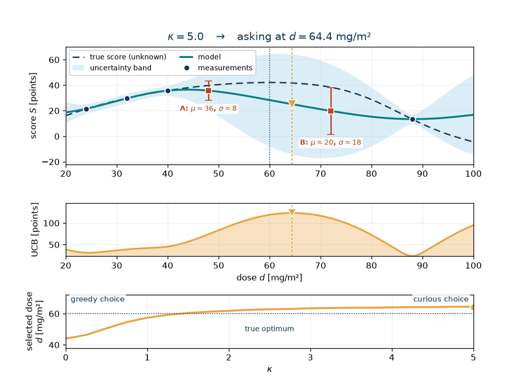

**UCB writes the trade-off as a knob you set yourself; EI reads it out of the data.**

## The acquisition is itself an optimization problem

$\mathbf x_{n+1}=\arg\max_{\mathbf x\in X} a(\mathbf x)$ — an optimization **inside** the optimization. The inner one is practically **free**:

- computed **from the model**, not the simulator — microseconds;
- **smooth**, only box bounds;
- but with **many local maxima**.

→ gradient method from many random starts, or a dense $61\times 61$ grid.

**Thompson sampling**, a fourth acquisition: draw **one whole function** from the posterior, take its maximum. No parameter — exploration takes care of itself.

Code: [`common.py`](https://github.com/tomasvicar/AUI-public/blob/master/lectures/bayesian-optimization/code/common.py) — the Gaussian process, all three acquisitions and the whole loop.

## 5 · Closing the loop

> We can build the model and we can compute the acquisition — what is left is to close the loop and to grade the result — before the model gets swapped.

## The algorithm on one slide

```
measure n0 initial points  # at random
while budget remains:
    fit model mu, sigma    # GP
    x_new = argmax a(x)    # acquisition
    y_new = f(x_new)       # expensive!
    add (x_new, y_new)
recommend argmax mu(x)     # not measured!
```

Four starting points + eight steps = **twelve evaluations**. [The whole method on one screen](https://github.com/tomasvicar/AUI-public/blob/master/lectures/bayesian-optimization/code/bo_from_scratch.py).

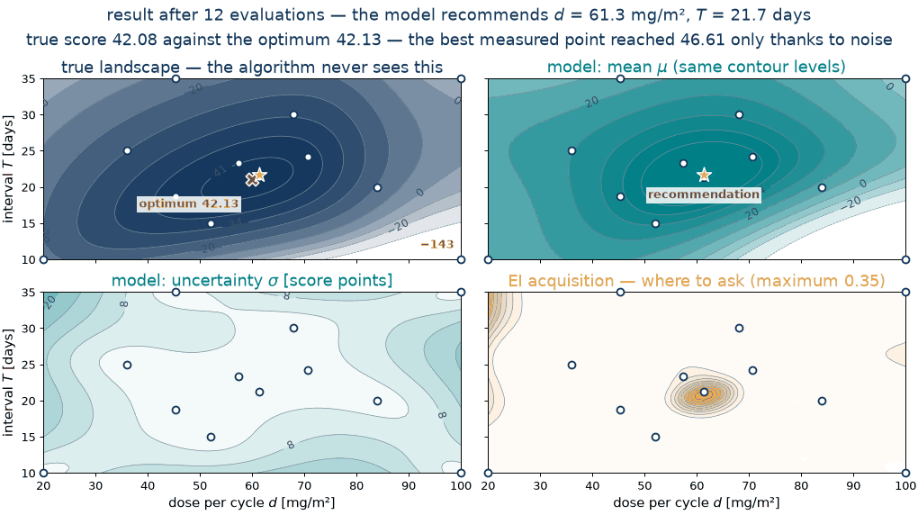

The last line is not a typo: recommend the **maximum of the model**, not the best measurement — measured **46.61**, true optimum **42.13**, model **42.08**.

## How do you know it worked?

**Simple regret** grades only the final recommendation $\hat{\mathbf x}_N$:

$$r_N=f(\mathbf x^\star)-f(\hat{\mathbf x}_N)$$

Reference run: $42.13-42.08\approx0.06$ after twelve evaluations.

Real problem: $f(\mathbf x^\star)$ unknown → plot the **best value so far** against evaluations.

Score 41: Bayesian optimization needs a median of **9 evaluations**; random search fails in half the runs even with **thirty**.

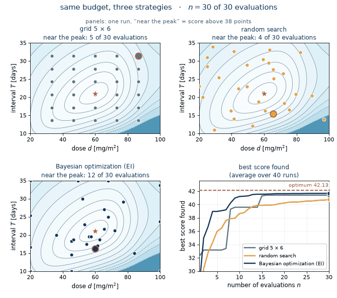

The fourth panel: an **average over forty runs** per strategy.

**A single run is an anecdote.** Compare methods as an **average over many runs** at the **same budget of evaluations**.

## 6 · When the variables are not numbers

> A kernel measures how far apart two settings are. What is the distance between an oral dose and an infusion — or between two optimizers?

## A kernel needs a distance

Add the **route of administration** to the running example — oral, IV bolus or IV infusion.

- the kernel compares settings through $\lVert\mathbf x-\mathbf x'\rVert$;
- coding the routes as 1, 2, 3 claims that a bolus lies **halfway** between oral and infusion;
- a **conditional** parameter (dose per fraction, radiotherapy only) has **no value** to plug in.

[figure not shown]

Mixed, branching spaces are the **rule** — the optimizer of a network, a staining protocol, the type of a classifier. The model has to cope **without a distance**.

## TPE: model the good settings, not the function

**Tree-structured Parzen estimator** — Bergstra et al., 2011. First on **one variable**: 12 random doses, each measured once.

1. **Split.** The threshold $y^*$ makes the best share $\gamma=0.25$ of the trials *good* — here 3 of 12 — the rest *bad*.
2. **Swap the condition.** The Gaussian process models $p(y\mid x)$ — the score given the setting. TPE models $p(x\mid y)$ — the setting given the score:
   $$\ell(x)=p(x\mid y\ge y^*),\qquad g(x)=p(x\mid y<y^*)$$

**KDE** (*kernel density estimate*, *Parzen window*): a Gaussian bump of width $h=8$ mg/m² on every trial, summed and divided by the count — a smooth histogram; plus one **flat imaginary trial**, so no density is ever zero.

[figure not shown]

## TPE: propose where good is likely and bad is not

**Idea:** a promising dose is **likely among the good** trials and **unlikely among the bad** ones — score it by the ratio
$$\frac{\ell(x)}{g(x)}$$

3. **Propose.** Draw 24 candidates from $\ell$ and keep the one with the largest ratio — here $d=54.5$.
4. **Measure, add, repeat** — the split and both densities are recomputed after every trial.

Bergstra et al.: under this model, maximizing $\ell/g$ **is** maximizing the expected improvement.

Nothing predicts a score: the model says **where** good settings are.

[figure not shown]

## TPE with a category: the same recipe

Now the toy with all **three** variables — 15 trials of a real run.

- the same split, then $\ell$ and $g$ **for each variable on its own**; the ratios of the variables are **multiplied**;
- a **number** gets a KDE, as on the previous slides;
- a **category** gets a **histogram** — counts instead of bumps, plus the imaginary trial.

No step ever asks how far apart two settings are.

[figure not shown]

## The same loop, a different box

```
measure n0 initial points     # at random
while budget remains:
    good | bad = best quarter # split
    fit l(x), g(x)            # per variable
    x_new = argmax l(x)/g(x)  # candidates from l
    y_new = f(x_new)          # expensive!
    add (x_new, y_new)
recommend best measured trial # no mu to maximize
```

Reference run, **4 + 12 evaluations**: IV infusion, $d=55.6$, $T=21.1$ — true score $47.77$ against the optimum $48.13$ (the toy adds $+6$ points for the infusion).

Forty runs, same budget, **median regret**: TPE $2.2$ points, random search $6.4$; within two points of the optimum in $42\,\%$ of runs against $15\,\%$. [The whole method on one screen](https://github.com/tomasvicar/AUI-public/blob/master/lectures/bayesian-optimization/code/tpe_from_scratch.py).

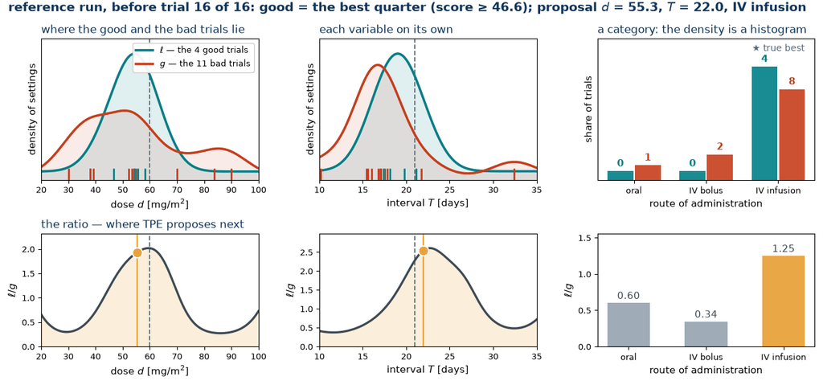

Against the Gaussian-process loop the model and the acquisition are swapped — and the **last line changed too**: with no $\mu$, TPE recommends the **best measurement**, and noise inflates it.

## Where TPE wins and where it loses

### Wins

- **categories and branches** — a histogram needs no distance; a branch is fitted only from the trials where it existed;
- **scales**: cost grows **linearly** with the trials, not as $n^3$ — thousands of trials, tens of variables;
- no kernel to choose, one knob $\gamma$;
- the default of **Optuna** and **Hyperopt**.

### Loses

- **each variable on its own** — the dose–interval **trade-off is invisible** (Optuna has a multivariate variant);
- a category is judged **only by the trials that used it**: in one of our runs both infusion starts hit awful doses and the infusion never got a second chance — regret $13.6$;
- **no $\mu$, no $\sigma$** — nothing to read off between trials, no model to recommend from.

**A few expensive numbers → Gaussian process. Categories, branches, hundreds of trials → TPE.** The loop is the same.

## 7 · In practice

> Where the method earns its keep, where it is pointless, and how to say which problem it was built for.

## Where else it is used

A six-legged robot

A leg **breaks off**; the robot searches a map of gaits for a new one — one evaluation is actually walking. A few dozen trials. *(Cully et al., Nature 2015.)*

A/B testing

One evaluation is days of traffic. A few discrete variants — a **multi-armed bandit**, not continuous optimization.

An MRI sequence

Flip angles, repetition and echo times: one measurement takes **tens of minutes** with the patient inside.

A microscope

Illumination, exposure, staining protocol: every wasted trial **bleaches the sample**.

Hyperparameter tuning — the best-known application — has a lecture of its own.

## When not to use Bayesian optimization

### Three situations where it is pointless

- **Cheap evaluation, two parameters** — a grid will do.
- **A hundred free cores** — random search parallelises, Bayesian optimization is **sequential**.
- **More than twenty parameters** — the Gaussian process never narrows down; TPE goes further, blind to interactions.

### What to use instead

| situation | what to use |
| --- | --- |
| cheap, 2 parameters | grid, random search |
| a hundred cores, cheap | random search |
| $10^5$ cheap evaluations | evolutionary, swarm search |
| hundreds of evaluations, tens of parameters | **CMA-ES** |
| tens of expensive evaluations | **Bayesian optimization** |

**CMA-ES**: a **normal distribution** instead of a model — more parameters, larger budget, parallel by itself.

**The method is chosen by what one evaluation costs.**

## Where Bayesian optimization sits

### What the problem is like

- continuous variables in a box (TPE: **categories** too);
- **many local maxima** — no formula, no derivative;
- **noisy** ($\sigma_\varepsilon = 2.0$ points);
- **expensive** — tens of evaluations.

### What the method is like

- **numerical and iterative**;
- **derivative-free**;
- **stochastic**;
- **sequential and model-based**.

| method | variable | objective | gradient |
| --- | --- | --- | --- |
| gradient descent | vector | differentiable formula | analytic |
| evolutionary, swarm search | vector | cheap fitness, thousands of calls | comparisons only |
| **Bayesian optimization** (GP) | a few parameters | expensive noisy black box | read off the model |
| **Bayesian optimization** (TPE) | numbers **and categories**, branches | expensive black box, more trials | none — densities of good vs. bad |

The structure of the **problem** narrows the choice of **method**, never the other way round.

## Takeaways

1. **When:** an expensive, noisy black box, no derivative, **tens of evaluations**.
2. **The uncertainty is worth more than the estimate.** $\mu$ says where it looks good, $\sigma$ where it still **could** be better.
3. **The acquisition function is that trade-off as a formula.** PI is greedy, UCB has a knob $\kappa$, **EI is a sensible default**.
4. **Recommend the maximum of the model, not the best measurement** — 46.61 measured versus 42.13 true.
5. **When not:** cheap evaluation → grid; many cores → random search; more than twenty parameters → the GP never narrows, TPE goes further.
6. **One run proves nothing:** simple regret for a run, an **average over many runs at the same budget** for a method.
7. **Categories or branches → TPE:** model **where the good settings are**, not the function — no distance needed, but each variable on its own and no $\mu$.

## Quick check

1. What makes an evaluation “expensive”, and which methods does that rule out?
2. What does the model return at an unmeasured point — and why is the second number the more important one?
3. What does the kernel decide, and what does its length scale mean?
4. How do PI, EI and UCB differ? Which bets on an unexplored point, and why?
5. Why recommend the maximum of the model, not the best measured value?
6. How do you tell that a run worked — and why does one run never settle which method is better?
7. What does TPE model instead of the function — and why does that make a categorical variable harmless?
8. Derivatives, noise, categories, the price of an evaluation: property of the problem or of the method?

## Sources and code

### Reading

- B. Shahriari et al.: *Taking the Human Out of the Loop* (Proc. IEEE, 2016) — the best first read;
- P. I. Frazier: *A Tutorial on Bayesian Optimization* (2018) — shorter, good on acquisitions;
- D. R. Jones, M. Schonlau, W. J. Welch: *Efficient Global Optimization of Expensive Black-Box Functions* (1998) — where EI comes from;
- J. Bergstra, R. Bardenet, Y. Bengio, B. Kégl: *Algorithms for Hyper-Parameter Optimization* (NeurIPS 2011) — where TPE comes from;
- C. E. Rasmussen, C. K. I. Williams: *Gaussian Processes for Machine Learning* (MIT Press, 2006) — free to download.

### Runnable code

- [`patient_simulator.py`](https://github.com/tomasvicar/AUI-public/blob/master/lectures/bayesian-optimization/code/patient_simulator.py) — the toy patient behind every number here;
- [`common.py`](https://github.com/tomasvicar/AUI-public/blob/master/lectures/bayesian-optimization/code/common.py) — GP, three acquisitions and the loop, plain NumPy;
- [`bo_from_scratch.py`](https://github.com/tomasvicar/AUI-public/blob/master/lectures/bayesian-optimization/code/bo_from_scratch.py) — the whole method on one screen, GP from `scikit-learn`;
- [`tpe_from_scratch.py`](https://github.com/tomasvicar/AUI-public/blob/master/lectures/bayesian-optimization/code/tpe_from_scratch.py) — TPE on dose, interval and route, plain NumPy.

In practice: **scikit-optimize**, **BoTorch** (Gaussian process) or **Optuna**, **Hyperopt** (TPE).